# Practical Machine Learning Course Project

RINIE

24 Disember 2015

# Background

Using devices such as Jawbone Up, Nike FuelBand, and Fitbit it is now possible to collect a large amount of data about personal activity relatively inexpensively. These type of devices are part of the quantified self movement - a group of enthusiasts who take measurements about themselves regularly to improve their health, to find patterns in their behavior, or because they are tech geeks. One thing that people regularly do is quantify how much of a particular activity they do, but they rarely quantify how well they do it. In this project, the goal is to use data from accelerometers on the belt, forearm, arm, and dumbell of 6 participants. They were asked to perform barbell lifts correctly and incorrectly in 5 different ways.

The training data for this project are available here: https://d396qusza40orc.cloudfront.net/predmachlearn/pml-training.csv

The test data are available here: https://d396qusza40orc.cloudfront.net/predmachlearn/pml-testing.csv

The data for this project come from this source: http://groupware.les.inf.puc-rio.br/har.

# Prediction Algorithm

```r
library(ggplot2)
library(caret)
library(e1071)
library(gbm)
library(doParallel)
library(survival)
library(splines)
library(plyr)
setwd("~/GitHub/PracticalMachineLearning")
```

# Load Data

1. Read Test and Training Data
2. Replace Missing Value

```r
training <- read.csv("~/GitHub/PracticalMachineLearning/pml-training.csv", na.strings=c("#DIV/0!"), row.names = 1)
testing <- read.csv("~/GitHub/PracticalMachineLearning/pml-testing.csv", na.strings=c("#DIV/0!"), row.names = 1)
```

```r
training <- training[, 6:dim(training)[2]]
treshold <- dim(training)[1]*0.95
gColumn <- !apply(training, 2, function(x) sum(is.na(x))>treshold || sum(x=="")>treshold)
training <- training[, gColumn]
bColumn <- nearZeroVar(training, saveMetrics=TRUE)
training <- training[, bColumn$nzv==FALSE]
training$classe = factor(training$classe)
```

3. Split Original Training Data and Cross Validation

```r
inTrain <- createDataPartition(training$classe, p=0.6)[[1]]
crossValid <- training[-inTrain,]
training <- training[inTrain,]
inTrain <- createDataPartition(crossValid$classe, p=0.75)[[1]]
crossValid_test <- crossValid[-inTrain,]
crossValid <- crossValid[inTrain,]

testing <- testing[, 6:dim(testing)[2]]
testing <- testing[, gColumn]
testing$classe <- NA
testing <- testing[, bColumn$nzv==FALSE]
```

```r
#model1 <- train(classe ~ ., data=training, method="rpart")
model2 <- train(classe ~ ., data=training, method="gbm")
#model3 <- train(classe ~ ., data=training, method="lda")

#predict1 <- predict(model1, crossValid)
predict2 <- predict(model2, crossValid)
#predict3 <- predict(model3, crossValid)
```

```r
#confusionMatrix(predict1, crossValid$classe)
confusionMatrix(predict2, crossValid$classe)
```

```
## Confusion Matrix and Statistics
##
##           Reference
## Prediction    A    B    C    D    E
##          A 1673   10    0    1    0
##          B    1 1111   19    4    4
##          C    0   17 1003   13    1
##          D    0    1    3  945   17
##          E    0    0    1    2 1060
##
## Overall Statistics
##
##                Accuracy : 0.984
##                  95% CI : (0.9805, 0.9871)
##     No Information Rate : 0.2844
##     P-Value [Acc > NIR] : < 2.2e-16
##
##                   Kappa : 0.9798
##  Mcnemar's Test P-Value : NA
##
## Statistics by Class:
##
##                      Class: A Class: B Class: C Class: D Class: E
## Sensitivity            0.9994   0.9754   0.9776   0.9793   0.9797
## Specificity            0.9974   0.9941   0.9936   0.9957   0.9994
## Pos Pred Value         0.9935   0.9754   0.9700   0.9783   0.9972
## Neg Pred Value         0.9998   0.9941   0.9953   0.9959   0.9954
## Prevalence             0.2844   0.1935   0.1743   0.1639   0.1838
## Detection Rate         0.2842   0.1888   0.1704   0.1606   0.1801
## Detection Prevalence   0.2861   0.1935   0.1757   0.1641   0.1806
## Balanced Accuracy      0.9984   0.9848   0.9856   0.9875   0.9895
```

```r
#confusionMatrix(predict3, crossValid$classe)
```

```r
#predict1 <- predict(model1, crossValid_test)
predict2 <- predict(model2, crossValid_test)
#predict3 <- predict(model3, crossValid_test)
```

```r
#accuracy <- sum(predict1 == crossValid_test$classe) / length(predict1)
accuracy <- sum(predict2 == crossValid_test$classe) / length(predict2)
#accuracy <- sum(predict3 == crossValid_test$classe) / length(predict3)
```

```r
varImpRF <- train(classe ~ ., data = training, method="gbm")
```

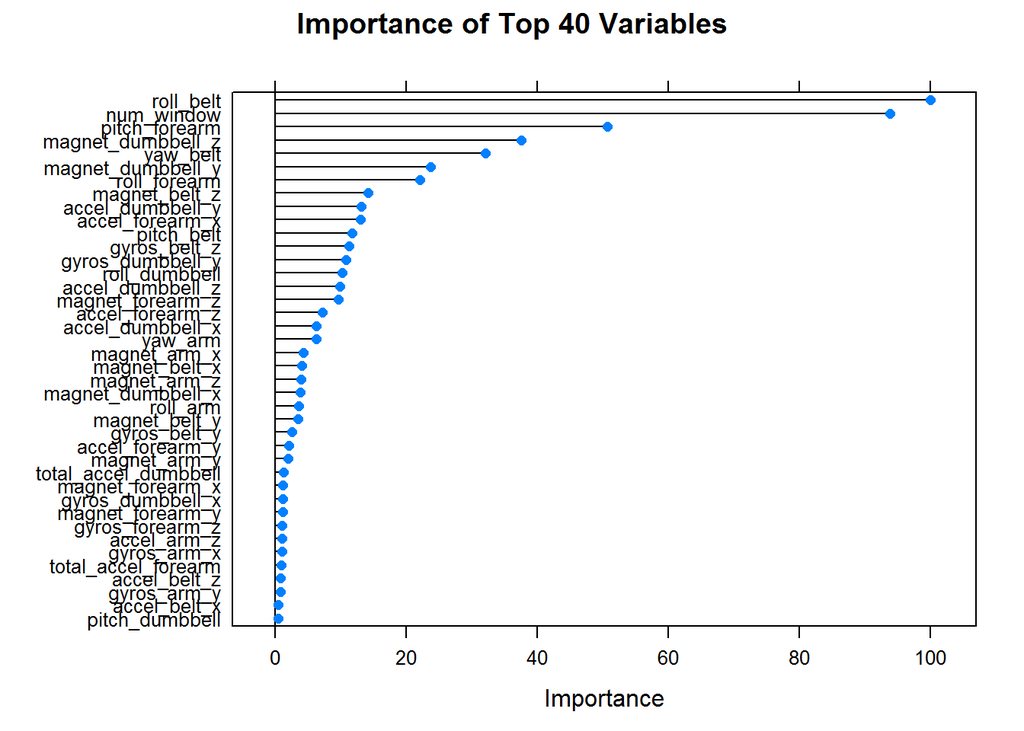

```r
varImpObj <- varImp(varImpRF)
plot(varImpObj, main = "Importance of Top 40 Variables", top = 40)
```

5. Preparing The Submission

```r
pml_write_files = function(x){
  n = length(x)
  for(i in 1:20){
    filename = paste0("problem_id_",i,".txt")
    write.table(x[i],file=filename,quote=FALSE,row.names=FALSE,col.names=FALSE)
  }
}

x <- testing

answers <- predict(model2, newdata=x)
answers
```

```
##  [1] B A B A A E D B A A B C B A E E A B B B
## Levels: A B C D E
```

```r
pml_write_files(answers)
```